# Dealing with Data

## Outline

- Two approaches
  - Base R
  - Piping
- Filtering
- Selecting
- Slicing
- Using non-standard data objects

## Indexing

## Base R Indexing

Base R has a very flexible/powerful indexing system with which to get at your data.

```r
x = rnorm(10)
x[x>0 & x<1]
```

```
## [1] 0.2774292 0.4291247 0.5060559
```

A more complicated approach. Values of y in which the absolute residuals of a regression on x are greater than 1.

```r
y[abs(resid(lm(y~x))) > 1]
```

This is not the way you should be doing things, but serves as an example of the possibilities

## Base R Indexing

Indexing

Lists (or dataframes)

- ['name'] [number] to extract list elements (including data.frames)
  - myList['myelement']
  - [[ can select a single element, where [] can return multiple
- $name also
  - myData$myvariable

Matrices (or dataframes)

- [rows, columns] or ['rownames', 'columnnames']
  - myData[1:3, 6:10]
  - myData[,'var1']

see ?Extract

## Base R Indexing

For this exercise, you will work with one of the many datasets that come with a basic R installation (?datasets), but note that packages typically come with their own as well.

For the following: Examine the **iris** dataset using the str (structure) function. You do not have to do anything to get the iris data, it's an object in the base R environment.

Create a separate object that just contains the the Species column of data

Create an object containing the 10-15th rows

Note the Petal Width of the 100th observation via indexing

Bonus: subset the data to only the virginica species. Hint- use ==

## Piping

## Piping

Piping is an alternative way to successively perform data manipulation and indexing (mainly through magrittr package).

- The most common way to do so is with this symbol %>%
- However, there are other ways to do so, and some with other packages

In conjunction with dplyr, it can make data manipulation and wrangling straightforward and with very clear code.

## Piping

Install the rvest package (read html functionality).

```r
# ☻ ☻ ☻
library(dplyr); library(rvest); library(stringr)
link ="http://www.inflationdata.com/inflation/Inflation_Rate/HistoricalInflation.aspx"
html(link) %>%                                        # read a webpage
  html_table(header = TRUE) %>%                       # grab all the tables
  `[[`(1) %>%                                         # grab the first table
  select(Year, Ave.) %>%                              # select specific columns
  rename(Ave = Ave.) %>%                              # rename
  filter(Year >= 2010) %>%                            # select certain rows
  mutate(AveNum = str_extract(Ave, '[0-9].[0-9]+'),
         AveNum2 = as.numeric(str_replace(Ave, ' %', '')))  # create new variables
```

```
##   Year    Ave AveNum AveNum2
## 1 2015          <NA>      NA
## 2 2014 1.62 %   1.62    1.62
## 3 2013 1.47 %   1.47    1.47
## 4 2012 2.07 %   2.07    2.07
## 5 2011 3.16 %   3.16    3.16
## 6 2010 1.64 %   1.64    1.64
```

## Piping

Note that you can assign the results of the piped operations to create an object

```r
myObjectSubset = mydata %>%
  filter(Year > 2000)
```

Piping is especially useful for visualization, and ggvis and newer more web-directed visualization packages will typically work with standard pipe operators.

```r
library(ggvis)
iris %>%
  ggvis(x=~Petal.Length, y=~Petal.Width) %>%
  layer_points(fill:='#ff5500', fillOpacity:=.35, size:=25) %>%
  layer_smooths(stroke:='darkred')
```

[output not shown]

## Filtering

## Filtering

Filtering (or Slicing) refers to subsetting by rows.

You have already seen how to do this with base R functionality with numbered indexing

the dplyr package has two primary functions for this

- filter
- slice

It also has other functions that can make the code clearer and easier to work wtih

```r
state.x77 %>%
  as.data.frame %>%
  filter(Frost >150) %>%
  slice(1:3)
```

```
##   Population Income Illiteracy Life Exp Murder HS Grad Frost   Area
## 1        365   6315        1.5    69.31   11.3    66.7   152 566432
## 2       2541   4884        0.7    72.06    6.8    63.9   166 103766
## 3       1058   3694        0.7    70.39    2.7    54.7   161  30920
```

## Selecting

## Selecting

Selecting here refers to the subset of columns, and with dplyr again you get enhanced functionality and clarity

```r
iris %>%
  select(starts_with('Petal')) %>%
  slice(1:2)
```

```
##   Petal.Length Petal.Width
## 1          1.4         0.2
## 2          1.4         0.2
```

## Aggregation

Oftentimes we engage in such operations in order to obtain summary information about groups.

```r
iris %>%
  group_by(Species) %>%
  summarise_each('mean')
```

```
## Source: local data frame [3 x 5]
##
##      Species Sepal.Length Sepal.Width Petal.Length Petal.Width
## 1     setosa        5.006       3.428        1.462       0.246
## 2 versicolor        5.936       2.770        4.260       1.326
## 3  virginica        6.588       2.974        5.552       2.026
```

```r
state.x77 %>%
  data.frame %>%
  mutate(region = state.region) %>%
  group_by(region) %>%
  tally
```

```
## Source: local data frame [4 x 2]
##
##          region  n
## 1     Northeast  9
## 2         South 16
## 3 North Central 12
## 4          West 13
```

## Basic Stats

Piping can be fed to various types of functions to make exploratory analysis easier.

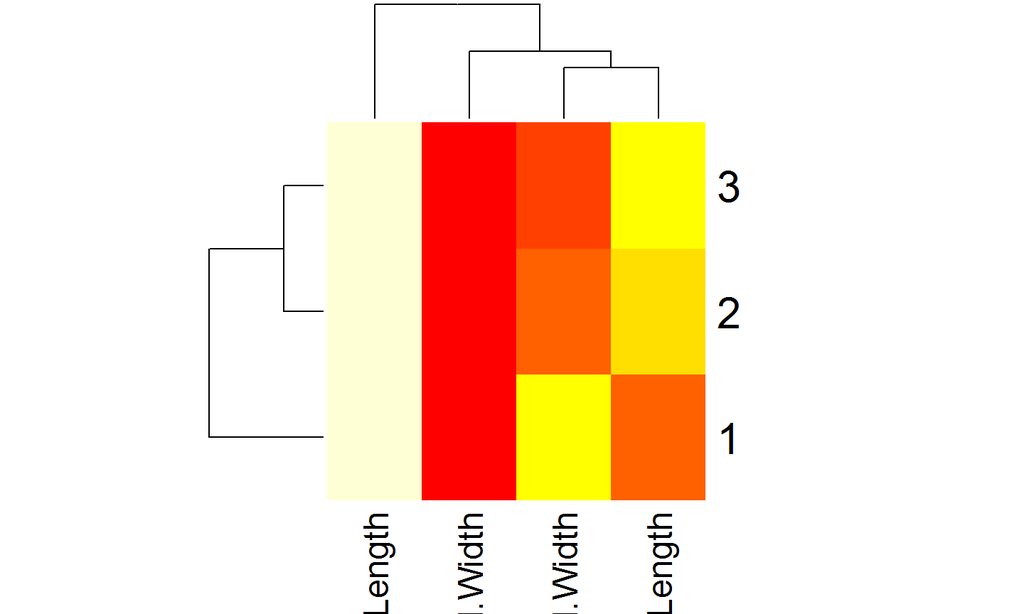

```r
iris %>%
  group_by(Species) %>%
  summarise_each('mean') %>%
  select(-Species) %>%
  as.matrix %>%
  heatmap
```

## Basic Stats

Piping can be fed to various types of functions to make exploratory analysis easier.

```r
iris %>%
  select(-Species) %>%
  cor %>%
  round(2)
```

```
##              Sepal.Length Sepal.Width Petal.Length Petal.Width
## Sepal.Length         1.00       -0.12         0.87        0.82
## Sepal.Width         -0.12        1.00        -0.43       -0.37
## Petal.Length         0.87       -0.43         1.00        0.96
## Petal.Width          0.82       -0.37         0.96        1.00
```

## Using non-standard data

Examples of non-standard data:

- text
- images
- spatial data (e.g. maps)
- web-oriented (json, xml)

Most of the data manipulation of such objects will be to put into a more analyzable format.

You will likely have to use package specific functions (e.g. jsonlite)

## Playtime

Link